```python
import pandas as pd
import numpy as np
import matplotlib.pyplot as plt
import seaborn as sns

# Carryover setup from last lecture
from sklearn.linear_model import LinearRegression
tips = sns.load_dataset('tips')

plt.style.use('seaborn-white')
plt.rc('figure', dpi=100, figsize=(7, 5))
plt.rc('font', size=12)

import warnings
warnings.simplefilter('ignore')
```

# Lecture 24 – Cross-Validation

## DSC 80, Spring 2022

### Announcements

- Lab 8 is due **today at 11:59PM**.
- Project 4 is due **Thursday, May 26th at 11:59PM**.
  - IMPORTANT: See [this post](https://campuswire.com/c/G325FA25B/feed/1511) for more public tests for Question 5.
- Remaining assignments: Lab 9 and Project 5.

### Agenda

- Train-test split.
- Hyperparameters.
- Cross-validation.
- Example: Decision trees 🌲.

## Train-test split

### Avoiding overfitting

- We won't know whether our model has **overfit** to our sample (training data) unless we get to see how well it performs on a new sample from the same DGP.
- **Idea 💡:** **Split** our sample into a **training set** and **test set**.
- Use **only** the training set to fit the model (i.e. find $w^*$).
- Use the test set to evaluate the model's error (RMSE, $R^2$).
- This is like "generating" new data from the same DGP!
  - *Similar* to bootstrapping (but not quite the same, because there is no resampling involved).
  - **If our sample is not representative of the DGP, this method has limited effectiveness!**

[figure not shown]

### Train-test split 🚆

`sklearn.model_selection.train_test_split` implements a train-test split for us! 🙏🏼

If `X` is an array/DataFrame of features and `y` is an array/Series of responses,

```
X_train, X_test, y_train, y_test = train_test_split(X, y, test_size=0.25)
```

randomly splits the features and responses into training and test sets, such that the test set contains 0.25 of the full dataset.

```python
from sklearn.model_selection import train_test_split
```

```python
# Read the documentation!
train_test_split?
```

Let's perform a train/test split on our `tips` dataset.

```python
X = tips.drop('tip', axis=1)
y = tips['tip']
X_train, X_test, y_train, y_test = train_test_split(X, y, test_size=0.2) # Don't have to choose 0.25
```

Before proceeding, let's check the sizes of `X_train` and `X_test`.

```python
print('Rows in X_train:', X_train.shape[0])
display(X_train.head())
print('Rows in X_test:', X_test.shape[0])
display(X_test.head())
```

```
Rows in X_train: 195
```

|  | total_bill | sex | smoker | day | time | size |
| --- | --- | --- | --- | --- | --- | --- |
| 230 | 24.01 | Male | Yes | Sat | Dinner | 4 |
| 11 | 35.26 | Female | No | Sun | Dinner | 4 |
| 78 | 22.76 | Male | No | Thur | Lunch | 2 |
| 170 | 50.81 | Male | Yes | Sat | Dinner | 3 |
| 41 | 17.46 | Male | No | Sun | Dinner | 2 |

```
Rows in X_test: 49
```

|  | total_bill | sex | smoker | day | time | size |
| --- | --- | --- | --- | --- | --- | --- |
| 186 | 20.90 | Female | Yes | Sun | Dinner | 3 |
| 228 | 13.28 | Male | No | Sat | Dinner | 2 |
| 188 | 18.15 | Female | Yes | Sun | Dinner | 3 |
| 234 | 15.53 | Male | Yes | Sat | Dinner | 2 |
| 239 | 29.03 | Male | No | Sat | Dinner | 3 |

```python
X_train.shape[0] / tips.shape[0]
```

```
0.7991803278688525
```

### Example prediction pipeline

Steps:

1. Fit a model on the training set.
2. Evaluate the model on the test set.

```python
tips.head()
```

|  | total_bill | tip | sex | smoker | day | time | size |
| --- | --- | --- | --- | --- | --- | --- | --- |
| 0 | 16.99 | 1.01 | Female | No | Sun | Dinner | 2 |
| 1 | 10.34 | 1.66 | Male | No | Sun | Dinner | 3 |
| 2 | 21.01 | 3.50 | Male | No | Sun | Dinner | 3 |
| 3 | 23.68 | 3.31 | Male | No | Sun | Dinner | 2 |
| 4 | 24.59 | 3.61 | Female | No | Sun | Dinner | 4 |

```python
X = tips[['total_bill', 'size']] # For this example, we'll use just the already-quantitative columns in tips
y = tips['tip']
X_train, X_test, y_train, y_test = train_test_split(X, y, test_size=0.2, random_state=1)
```

Here, we'll use a stand-alone `LinearRegression` model without a `Pipeline`, but this process would work the same if we were using a `Pipeline`.

```python
lr = LinearRegression()
lr.fit(X_train, y_train)
```

```
LinearRegression()
```

Let's check our model's performance on the **training** set first.

```python
from sklearn.metrics import mean_squared_error # built-in RMSE/MSE function
```

```python
pred_train = lr.predict(X_train)
rmse_train = mean_squared_error(y_train, pred_train, squared=False)
rmse_train
```

```
0.9803205287924736
```

And the **test** set:

```python
pred_test = lr.predict(X_test)
rmse_test = mean_squared_error(y_test, pred_test, squared=False)
rmse_test
```

```
1.138177129113125
```

Since `rmse_train` and `rmse_test` are similar, it **doesn't seem like our model is overfitting** to the training data. If `rmse_test` was much larger than `rmse_train`, it would be evidence that our model is unable to **generalize well**.

## Hyperparameters

### Example: Polynomial regression

Recall, last class we looked at an example of **polynomial regression**.

[figure not shown]

When building these models:

- We **got to choose** the degree of the polynomials (i.e. we chose 1, 3, and 15).
- We didn't get to choose the exact formulas for the three polynomials – their formulas were **learned from data**.

### Parameters vs. hyperparameters

- A **parameter** defines the relationship between variables in a model.
  - **We learn parameters from data**.
  - For instance, suppose we fit a degree 3 polynomial to data, and end up with

    $$H(x) = 1 - 2x + 13x^2 - 4x^3$$
  - 1, -2, 13, and -4 are parameters.
- A **hyperparameter** is a parameter that we get to choose **before our model is fit to the data**.
  - Think of hyperparameters as knobs 🎛 – **we get to pick and tune them!**
  - **Polynomial degree** was a hyperparameter in the previous example, and we tried three different values – 1, 3, and 15.
- **Question:** How do we choose the "right" hyperparameter(s)?

### Training error vs. test error

- We know that a model's performance on a **test set** is a good estimate of its ability to generalize to unseen data.
- We want to find the hyperparameter that leads to the best **test set performance**.
- Idea:
  1. Come up with a **list** of hyperparameters to try.
  2. For each hyperparameter, train the model on the training set and compute its performance on the test set.
  3. Pick the hyperparameter with the best performance on the test set.

### Training error vs. test error

- Let's try this strategy on the dataset ("Sample 1") from last class.
- We'll try to fit a polynomial model on the dataset; we'll choose the polynomial's degree from the list [1, 2, ..., 15].

```python
sample_1 = pd.read_csv('data/sample-1.csv')
sample_1.head()
```

|  | x | y |
| --- | --- | --- |
| 0 | -2.000000 | -5.999036 |
| 1 | -1.949495 | -7.331676 |
| 2 | -1.898990 | -9.180925 |
| 3 | -1.848485 | -3.470179 |
| 4 | -1.797980 | -3.707370 |

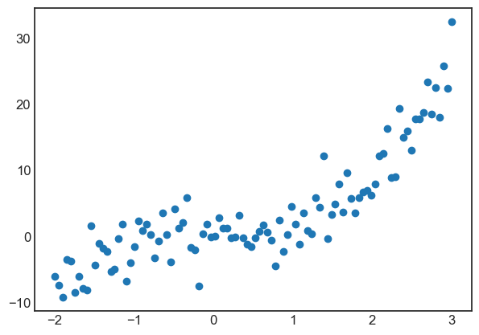

```python
plt.scatter(sample_1['x'], sample_1['y']);
```

First, we perform a train-test split.

```python
X = sample_1[['x']]
y = sample_1['y']

X_train, X_test, y_train, y_test = train_test_split(X, y, random_state=100) # random_state is like np.random.seed
```

Now, we'll implement the logic from the previous slide.

```python
from sklearn.pipeline import Pipeline
from sklearn.preprocessing import PolynomialFeatures
```

```python
train_errs = []
test_errs = []

for d in range(1, 16):
    pl = Pipeline([('poly', PolynomialFeatures(d)), ('lin-reg', LinearRegression())])
    pl.fit(X_train, y_train)
    train_errs.append(mean_squared_error(y_train, pl.predict(X_train), squared=False))
    test_errs.append(mean_squared_error(y_test, pl.predict(X_test), squared=False))
```

Let's look at both the training RMSEs and test RMSEs we computed.

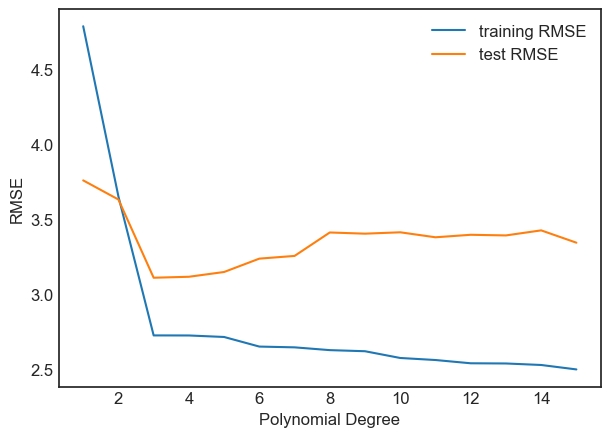

```python
plt.plot(range(1, 16), train_errs, label='training RMSE')
plt.plot(range(1, 16), test_errs, label='test RMSE')
plt.xlabel('Polynomial Degree')
plt.ylabel('RMSE')
plt.legend();
```

**Observations:**

- Training error appears to decrease as polynomial degree increases.
- Testing error appears to decrease until an "elbow", and then increases again.

Here, we'd choose a degree of 3, since that degree has the **lowest test error**.

### Training error vs. test error

The pattern we saw in the previous example is true more generally.

[figure not shown]

We pick the hyperparameter(s) at the "valley" of test error.

Note that training error **tends** to underestimate test error, but it doesn't have to – i.e., it is possible for test error to be lower than training error (say, if the test set is "easier" to predict than the training set).

### Conducting train-test splits

- Recall, **training data** is used to fit our model, and **test data** is used to evaluate our model.

[figure not shown]

- **Question:** *How* should we split?
  - `sklearn`'s `train_test_split` splits **randomly**, which usually works well.
  - However, if there is some element of **time** in the training data (say, when predicting the future price of a stock), a better split is "past" and "future".
- **Question:** How *large* should the split be, e.g. 90%-10% vs. 75%-25%?
  - There's a tradeoff – a larger training set should lead to a "better" model, while a larger test set should lead to a better estimate of our model's ability to generalize.
  - There's no "right" choice, but we usually choose between a split between the ranges above.

### But wait...

- With our current strategy, we are choosing the hyperparameter that creates the model that **performs best on the test set**.
- As such, we are **overfitting to the test set** – the best hyperparameter for the test set might not be the best hyperparameter for a totally unseen dataset!
- It seems like we need **another** split.

## Cross-validation

### A single validation set

[figure not shown]

1. Split the data into three sets: **training**, **validation**, and **test**.
1. For each hyperparameter choice, **train** the model only on the **training set**, and **evaluate** the model's performance on the **validation set**.
1. Find the hyperparameter with the best **validation** performance.
1. Retrain the final model on the **training** and **validation** sets, and report its performance on the **test set**.

**Issue:** This strategy is too dependent on the **validation** set, which may be small and/or not a representative sample of the data.

### $k$-fold cross-validation

Instead of relying on a single validation set, we can create $k$ validation sets, where $k$ is some positive integer (5 in the following example).

[figure not shown]

Since each data point is used for training $k-1$ times and validation once, the (averaged) validation performance should be a good metric of a model's ability to generalize to unseen data.

### $k$-fold cross-validation

First, **shuffle** the dataset randomly and **split** it into $k$ disjoint groups. Then:

- For each hyperparameter:
  - For each unique group:
    - Let the unique group be the "validation set".
    - Let all other groups be the "training set".
    - Train a model using the selected hyperparameter on the training set.
    - Evaluate the model on the validation set.
  - Compute the **average** validation score (e.g. RMSE) for the particular hyperparameter.
- Choose the hyperparameter with the best average validation score.

### Creating folds in `sklearn`

`sklearn` has a `KFold` class that splits data into training and validation folds.

```python
from sklearn.model_selection import KFold
```

Let's use a simple dataset for illustration.

```python
data = np.arange(10, 70, 10)
data
```

```
array([10, 20, 30, 40, 50, 60])
```

Let's instantiate a `KFold` object with $k=3$.

```python
kfold = KFold(3, shuffle=True, random_state=1)
kfold
```

```
KFold(n_splits=3, random_state=1, shuffle=True)
```

Finally, let's use `kfold` to `split` `data`:

```python
for train, val in kfold.split(data):
    print(f'train: {data[train]}, validation: {data[val]}')
```

```
train: [10 40 50 60], validation: [20 30]
train: [20 30 40 60], validation: [10 50]
train: [10 20 30 50], validation: [40 60]
```

Note that each value in `data` is used for validation exactly once and for training exactly twice. Also note that because we set `shuffle=True` the groups are not simply `[10, 20]`, `[30, 40]`, and `[50, 60]`.

### "Manual" $k$-fold cross-validation in `sklearn`

- Let's use `KFold` to perform $k$-fold cross validation in order to help us pick a degree for polynomial regression from the list [1, 2, ..., 15].
- We'll use $k=5$ (a common choice, and the default in `sklearn`).
- For the sake of example, we'll suppose `sample_1` is our "training + validation data", i.e. that our test data is in some other dataset.
  - If this were not true, we'd first need to split `sample_1` into train and test.

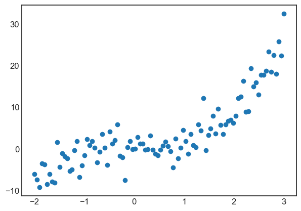

```python
plt.scatter(sample_1['x'], sample_1['y']);
```

```python
kfold = KFold(5, shuffle=True, random_state=1)
```

```python
errs_df = pd.DataFrame()

for d in range(1, 16):
    errs = []
    for train, val in kfold.split(sample_1):
        # Separate the data into a training set and validation set
        data_train, data_val = sample_1.iloc[train], sample_1.iloc[val]

        # Fit the model on the training set
        pl = Pipeline([('poly', PolynomialFeatures(d)), ('lin-reg', LinearRegression())])
        pl.fit(data_train[['x']], data_train['y'])

        # Compute the model's validation error
        val_err = mean_squared_error(data_val['y'], pl.predict(data_val[['x']]), squared=False)
        errs.append(val_err)

    errs_df[f'Deg {d}'] = errs

errs_df.index = [f'Fold {i}' for i in range(1, 6)]
```

```python
errs_df
```

|  | Deg 1 | Deg 2 | Deg 3 | Deg 4 | Deg 5 | Deg 6 | Deg 7 | Deg 8 | Deg 9 | Deg 10 | Deg 11 | Deg 12 | Deg 13 | Deg 14 | Deg 15 |
| --- | --- | --- | --- | --- | --- | --- | --- | --- | --- | --- | --- | --- | --- | --- | --- |
| Fold 1 | 4.199778 | 3.606615 | 2.831147 | 2.828540 | 2.841994 | 2.858593 | 3.024709 | 3.065179 | 3.064011 | 3.087646 | 3.069269 | 3.035684 | 3.158415 | 3.185333 | 3.267513 |
| Fold 2 | 6.332986 | 4.758864 | 3.359064 | 3.463889 | 4.039780 | 4.080516 | 4.156041 | 4.197769 | 4.251904 | 4.066354 | 3.876995 | 3.870712 | 3.795465 | 3.986883 | 3.487144 |
| Fold 3 | 4.513414 | 3.091568 | 2.824030 | 2.904488 | 3.078070 | 3.201268 | 3.207738 | 3.224326 | 3.249295 | 3.317992 | 3.282708 | 3.448616 | 3.507821 | 3.561160 | 3.492002 |
| Fold 4 | 4.554400 | 4.044258 | 3.048785 | 3.053034 | 3.148588 | 3.093417 | 3.104223 | 3.150751 | 3.322878 | 3.358298 | 3.373014 | 3.326871 | 3.529446 | 3.487267 | 4.238141 |
| Fold 5 | 4.285422 | 3.594867 | 2.636512 | 2.676925 | 2.709439 | 3.267328 | 3.271033 | 3.268576 | 3.398126 | 3.324115 | 3.484460 | 3.498631 | 3.499423 | 3.549985 | 3.391811 |

Note that for each choice of degree (our hyperparameter), we have **five** RMSEs, one for each "fold" of the data.

We should choose the degree with the lowest **average** validation RMSE.

```python
errs_df.mean()
```

```
Deg 1     4.777200
Deg 2     3.819234
Deg 3     2.939908
Deg 4     2.985375
Deg 5     3.163574
Deg 6     3.300225
Deg 7     3.352749
Deg 8     3.381320
Deg 9     3.457243
Deg 10    3.430881
Deg 11    3.417289
Deg 12    3.436103
Deg 13    3.498114
Deg 14    3.554126
Deg 15    3.575322
dtype: float64
```

```python
errs_df.mean().idxmin()
```

```
'Deg 3'
```

Note that if we only performed non-$k$-fold cross-validation, we might pick a different degree:

```python
for fold in errs_df.index:
    print(errs_df.loc[fold].idxmin())
```

```
Deg 4
Deg 3
Deg 3
Deg 3
Deg 3
```

### "Semi-automatic" $k$-fold cross validation in `sklearn`

The `cross_val_score` function in `sklearn` implements a few of the previous steps in one.

```
cross_val_score(estimator, data, target, cv)
```

Specifically, it takes in:

- A `Pipeline` or estimator **that has not already been `fit`**
- Training data
- A value of $k$ (through the `cv` argument)
- (Optionally) A `scoring` metric

and performs $k$-fold cross-validation, returning the values of the scoring metric on each fold.

```python
from sklearn.model_selection import cross_val_score
```

```python
errs_df_auto = pd.DataFrame()

for d in range(1, 16):
    pl = Pipeline([('poly', PolynomialFeatures(d)), ('lin-reg', LinearRegression())])

    # The `scoring` argument is used to specify that we want to compute the RMSE; the default is R^2
    # It is called "neg" RMSE because by default sklearn likes to "maximize" scores
    errs = cross_val_score(pl, sample_1[['x']], sample_1['y'], cv=5, scoring='neg_root_mean_squared_error')
    errs_df_auto[f'Deg {d}'] = -errs # Negate to turn positive (sklearn computed negative RMSE)

errs_df_auto.index = [f'Fold {i}' for i in range(1, 6)]
```

```python
errs_df_auto
```

|  | Deg 1 | Deg 2 | Deg 3 | Deg 4 | Deg 5 | Deg 6 | Deg 7 | Deg 8 | Deg 9 | Deg 10 | Deg 11 | Deg 12 | Deg 13 | Deg 14 | Deg 15 |
| --- | --- | --- | --- | --- | --- | --- | --- | --- | --- | --- | --- | --- | --- | --- | --- |
| Fold 1 | 4.789975 | 12.814865 | 5.040947 | 4.927487 | 8.853939 | 13.150006 | 18.023855 | 149.574851 | 897.759319 | 718.403458 | 841.062760 | 3964.733244 | 55940.500810 | 55106.074263 | 202369.608764 |
| Fold 2 | 3.971600 | 5.359234 | 3.186076 | 3.218728 | 3.194274 | 3.007987 | 3.077643 | 3.127204 | 3.098704 | 3.559998 | 4.260110 | 5.223040 | 4.996440 | 8.254853 | 6.843680 |
| Fold 3 | 4.770176 | 2.557932 | 2.083676 | 2.110708 | 2.100757 | 2.013973 | 2.018524 | 1.996626 | 2.186183 | 3.946495 | 3.889999 | 3.962834 | 4.021369 | 4.912291 | 4.772074 |
| Fold 4 | 6.134098 | 4.656187 | 2.925225 | 2.932392 | 3.030811 | 3.040322 | 3.144730 | 3.160528 | 3.310559 | 3.070833 | 2.931583 | 4.200841 | 3.894982 | 5.317150 | 3.238713 |
| Fold 5 | 11.699003 | 11.916631 | 3.235882 | 4.372698 | 33.584482 | 51.745272 | 56.510688 | 92.223491 | 335.804723 | 1168.510898 | 1128.161798 | 8074.430848 | 8910.388508 | 9651.165907 | 139023.154682 |

```python
errs_df_auto.mean().idxmin()
```

```
'Deg 3'
```

That was considerably easier! Next class, we'll look at how to streamline this procedure even more (no loop necessary).

*Note:* You may notice that the RMSEs in the above table, particularly in Folds 1 and 5, are much higher than they were in the manual method. Can you think of reasons why, and how we might fix this? (*Hint: Go back to the "manual" method and switch `shuffle` to `False`. What do you notice?*)

### Summary: Generalization

1. Split the data into two sets: **training** and **test**.
2. Use only the **training** data when designing, training, and tuning the model.
   - Use **cross-validation** to choose hyperparameters and estimate the model's ability to generalize.
   - Do not ❌ look at the **test** data in this step!
3. Commit to your final model and train it using the entire **training** set.
4. Test the data using the **test** data. If the performance (e.g. RMSE) is not acceptable, return to step 2.
5. Finally, train on **all available data** and ship the model to production! 🛳

🚨 This is the process you should **always** use! 🚨

### Discussion Question 🤔

- Suppose you have a training dataset with 1000 rows.
- You want to decide between 20 hyperparameters for a particular model.
- To do so, you perform 10-fold cross-validation.
- **How many times is the first row in the training dataset (`X.iloc[0]`) used for training a model?**